# Randomized Block Design

Author

Affiliation

Undergrad Hernandes Peres

[Biometrics Lab.](https://biometria.ufv.br/)

[figure not shown]

[figure not shown]

## Example 1

```r
rm(list = ls())
setwd("C:/StatisticsCourse/07-DBC")
data <- read.table("DataRBD.txt", header = TRUE)
data$trat <- as.factor(data$trat)
data$bloco <- as.factor(data$bloco)

n <- length(prod)
```

### 1. Field layout

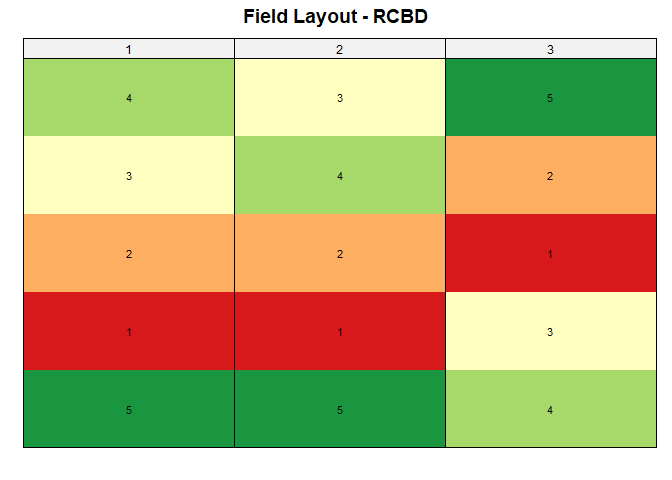

```r
source("C:/StatisticsCourse/05-DIC/ExperimentalDesignFunction.R")

set.seed(7)
field_layout(data = data,
             n_row = nrow(data)/length(levels(data$bloco)),
             n_col = length(levels(data$bloco)),
             design = "DBC")$plot
```

### 2. Basic Descriptive Statistics

```r
colnames(data)[colnames(data) == "rep"] <- "bloco"

mean.prodt <- tapply(data$prod, data$trat, mean)
var.prodt <- tapply(data$prod, data$trat, var)
mean.prodb <- tapply(data$prod, data$bloco, mean)
var.prodb <- tapply(data$prod, data$bloco, var)
```

### 3. ANOVA and Residuals

```r
fit1 <- aov(data$prod ~ data$bloco + data$trat)
res <- residuals(fit1)
```

Residual Diagnostics

**Checking residuals normality**

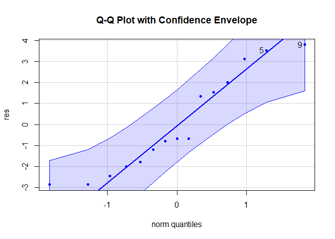

```
[1] 9 5
```

```r
xb <- mean(res)
sx <- sd(res)

library(car)

qqPlot(res,
       main = "Q-Q Plot with Confidence Envelope",
       col = "blue",
       pch = 20,
       envelope = 0.95)  # 95% confidence envelope
```

```r
library(nortest)
tests <- list(
  ks.test(res, "pnorm", xb, sx),
  lillie.test(res),
  cvm.test(res),
  shapiro.test(res),
  sf.test(res),
  ad.test(res))

results <- data.frame(Statistic = sapply(tests, function(x) x$statistic),
                      p_value = sapply(tests, function(x) x$p.value),
                      row.names = sapply(tests, function(x) x$method))

knitr::kable(results)
```

|  | Statistic | p_value |
| --- | --- | --- |
| Exact one-sample Kolmogorov-Smirnov test | 0.2114754 | 0.4522217 |
| Lilliefors (Kolmogorov-Smirnov) normality test | 0.2114754 | 0.0697293 |
| Cramer-von Mises normality test | 0.0886424 | 0.1467719 |
| Shapiro-Wilk normality test | 0.9044138 | 0.1111801 |
| Shapiro-Francia normality test | 0.9267511 | 0.2086352 |
| Anderson-Darling normality test | 0.5266985 | 0.1493575 |

**Checking residual Homoscedasticity**

```r
bartlett.test(res, data$trat)
```

```
    Bartlett test of homogeneity of variances

data:  res and data$trat
Bartlett's K-squared = 0.78393, df = 4, p-value = 0.9406
```

**Checking residuals independence**

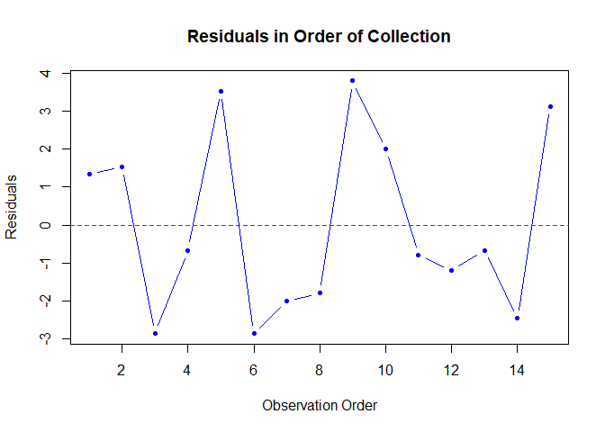

```r
plot(res,
     type = "b",
     pch = 20,
     col = "blue",
     xlab = "Observation Order",
     ylab = "Residuals",
     main = "Residuals in Order of Collection")
abline(h = 0, col = "red", lty = 2)
```

### 4. ANOVA Summary

- Before moving forward, it’s important to understand some of the parameters that distinguish the randomized block design (RBD) from the completely randomized design (CRD).
- The randomized block design is used to control disturbing factors that could compromise the homogeneity of experimental conditions.
- Blocks are employed to account for differences between experimental units, such as soil fertility, water availability, light exposure, and others.
- All levels of a factor must be tested within each block, which should be internally homogeneous. Randomization is restricted and must be performed within each block.
- If the source of variation is not being controlled, it will be absorbed into the residual, which may increase the value of $QM_{res}$.
- An increase in $QM_{res}$ can make it harder to detect a significant effect between treatments, even when they may actually differ

So now, in RBD, the model is:
$$y_{ik} = \mu + \tau_i + \beta_k + \varepsilon_{ik}$$

We already know how to compute $SQ_t$, $SQ_{trat}$ and $SQ_{res}$ for a CRD, but know we need to include another factor that helps to reduce the $QM_{res}$, which is the $SQ_{b}$

$$SQ_t = \sum_{ik} y_{ik}^2-C, \quad \text{where} \quad C = \frac{\left( \sum_{ik} y_{ik} \right)^2}{n}$$

$$SQ_{trat} = \sum \frac{T_i^2}{k} - C$$
$$SQ_b = \sum \frac{B_k^2}{I} - C$$
Thus, we are that the $SQ_{res}$ is compute by:
$$SQ_{res} = SQ_{t} - SQ_{trat} - SQ_b$$

Utilizing the `ExpDes.pt` package we can run ANOVA for a Randomized Completed Blocks Design, using `dbc()` function.

```r
library(ExpDes.pt)
fit3 <- dbc(data$trat, data$bloco, data$prod, quali = TRUE,
            mcomp = "duncan", sigT = 0.05, sigF = 0.05)
```

```
------------------------------------------------------------------------
Quadro da analise de variancia
------------------------------------------------------------------------
           GL    SQ  QM      Fc   Pr>Fc
Tratamento  4  15.6 3.9 0.40206 0.80237
Bloco       2  12.4 6.2 0.63918 0.55268
Residuo     8  77.6 9.7
Total      14 105.6
------------------------------------------------------------------------
CV = 18.76 %

------------------------------------------------------------------------
Teste de normalidade dos residuos
valor-p:  0.1111801
De acordo com o teste de Shapiro-Wilk a 5% de significancia, os residuos podem ser considerados normais.
------------------------------------------------------------------------

------------------------------------------------------------------------
Teste de homogeneidade de variancia
valor-p:  0.8106017
De acordo com o teste de oneillmathews a 5% de significancia, as variancias podem ser consideradas homogeneas.
------------------------------------------------------------------------

De acordo com o teste F, as medias nao podem ser consideradas diferentes.
  Niveis   Medias
1      1 14.66667
2      2 16.66667
3      3 17.00000
4      4 17.00000
5      5 17.66667
------------------------------------------------------------------------
```

As we can se the F test from the ANOVA is not significant, then we should not follow with the multiple comparison

## Example 2

Cleaning environment and loading data

```r
rm(list=ls())

data <- read.table("DataSoja.txt", header=TRUE)
data$trat <- factor(data$trat)
data$bloco <- factor(data$bloco)

knitr::kable(data)
```

| trat | bloco | altpvagem | altplanta | estande | prod_ton |
| --- | --- | --- | --- | --- | --- |
| T1 | 1 | 11.6 | 71.2 | 8.36 | 3.3524 |
| T1 | 2 | 13.6 | 70.0 | 10.16 | 3.1036 |
| T1 | 3 | 12.0 | 67.6 | 9.42 | 2.6478 |
| T1 | 4 | 10.4 | 68.6 | 11.06 | 2.8636 |
| T1 | 5 | 12.8 | 73.4 | 8.12 | 3.1438 |
| T1 | 6 | 13.0 | 73.8 | 9.66 | 3.3844 |
| T2 | 1 | 11.6 | 75.4 | 9.52 | 3.4224 |
| T2 | 2 | 12.0 | 75.6 | 11.52 | 3.1036 |
| T2 | 3 | 9.6 | 76.0 | 10.32 | 2.6478 |
| T2 | 4 | 11.6 | 72.6 | 11.56 | 2.8636 |
| T2 | 5 | 10.8 | 69.0 | 12.18 | 3.1438 |
| T2 | 6 | 12.2 | 66.8 | 10.56 | 3.3844 |
| T3 | 1 | 11.6 | 77.2 | 11.42 | 3.2004 |
| T3 | 2 | 9.0 | 79.6 | 11.96 | 2.9382 |
| T3 | 3 | 11.2 | 72.6 | 12.02 | 2.6086 |
| T3 | 4 | 12.0 | 73.4 | 11.58 | 3.0242 |
| T3 | 5 | 10.4 | 68.4 | 12.14 | 2.5750 |
| T3 | 6 | 12.7 | 67.2 | 11.98 | 2.7968 |
| T4 | 1 | 13.8 | 64.6 | 9.70 | 3.1166 |
| T4 | 2 | 14.8 | 57.6 | 9.82 | 2.6328 |
| T4 | 3 | 15.8 | 47.4 | 11.54 | 1.1206 |
| T4 | 4 | 17.8 | 52.2 | 9.56 | 1.3640 |
| T4 | 5 | 14.6 | 64.0 | 11.98 | 1.6806 |
| T4 | 6 | 13.2 | 63.4 | 10.94 | 1.9792 |
| T5 | 1 | 19.0 | 88.0 | 13.50 | 2.9342 |
| T5 | 2 | 17.8 | 75.6 | 13.78 | 3.2634 |
| T5 | 3 | 20.0 | 82.0 | 13.66 | 3.3276 |
| T5 | 4 | 16.6 | 79.4 | 13.58 | 3.1326 |
| T5 | 5 | 17.8 | 81.4 | 11.22 | 3.4582 |
| T5 | 6 | 18.8 | 77.2 | 9.76 | 3.9386 |
| T6 | 1 | 16.0 | 64.8 | 13.66 | 3.3344 |
| T6 | 2 | 14.2 | 69.0 | 13.68 | 3.5038 |
| T6 | 3 | 15.0 | 64.8 | 14.96 | 3.8820 |
| T6 | 4 | 14.6 | 63.2 | 14.60 | 3.3734 |
| T6 | 5 | 12.8 | 56.0 | 12.62 | 4.3914 |
| T6 | 6 | 14.8 | 56.4 | 11.80 | 3.6828 |
| T7 | 1 | 21.4 | 64.4 | 13.26 | 3.1046 |
| T7 | 2 | 21.6 | 68.0 | 12.86 | 3.2698 |
| T7 | 3 | 21.4 | 64.4 | 11.14 | 3.5612 |
| T7 | 4 | 20.2 | 62.6 | 11.72 | 3.3908 |
| T7 | 5 | 21.1 | 63.2 | 12.10 | 2.8176 |
| T7 | 6 | 15.8 | 67.4 | 14.18 | 3.2490 |
| T8 | 1 | 19.8 | 84.2 | 10.18 | 2.8862 |
| T8 | 2 | 20.0 | 74.2 | 9.84 | 3.5840 |
| T8 | 3 | 18.6 | 79.4 | 9.82 | 4.1674 |
| T8 | 4 | 16.8 | 72.0 | 9.62 | 3.9022 |
| T8 | 5 | 19.4 | 85.4 | 9.02 | 4.0408 |
| T8 | 6 | 18.2 | 82.0 | 9.64 | 3.8710 |

### 1. Field layout

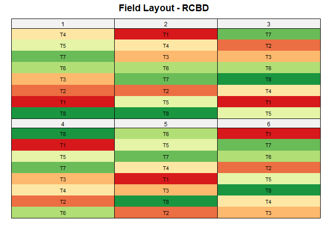

```r
source("C:/StatisticsCourse/05-DIC/ExperimentalDesignFunction.R")

set.seed(7)
field_layout(data = data,
             n_row = nrow(data)/length(levels(data$bloco)),
             n_col = length(levels(data$bloco)),
             design = "DBC")$plot
```

### 2. ANOVA and residuals

```r
fit_list <- list(altpvagem = aov(data$altpvagem ~ data$bloco + data$trat),
                 altplanta = aov(data$altplanta ~ data$bloco + data$trat),
                 estande = aov(data$estande ~ data$bloco + data$trat),
                 prod_ton = aov(data$prod_ton ~ data$bloco + data$trat))

residuals_list <- lapply(fit_list, residuals)
lapply(fit_list, anova)
```

```
$altpvagem
Analysis of Variance Table

Response: data$altpvagem
           Df Sum Sq Mean Sq F value    Pr(>F)
data$bloco  5   3.85   0.769  0.3639    0.8697
data$trat   7 534.81  76.401 36.1341 3.465e-14 ***
Residuals  35  74.00   2.114
---
Signif. codes:  0 '***' 0.001 '**' 0.01 '*' 0.05 '.' 0.1 ' ' 1

$altplanta
Analysis of Variance Table

Response: data$altplanta
           Df  Sum Sq Mean Sq F value    Pr(>F)
data$bloco  5  159.71   31.94  1.5573    0.1978
data$trat   7 2650.69  378.67 18.4624 4.955e-10 ***
Residuals  35  717.86   20.51
---
Signif. codes:  0 '***' 0.001 '**' 0.01 '*' 0.05 '.' 0.1 ' ' 1

$estande
Analysis of Variance Table

Response: data$estande
           Df Sum Sq Mean Sq F value    Pr(>F)
data$bloco  5  3.257  0.6515  0.5479    0.7388
data$trat   7 90.586 12.9408 10.8825 3.321e-07 ***
Residuals  35 41.620  1.1891
---
Signif. codes:  0 '***' 0.001 '**' 0.01 '*' 0.05 '.' 0.1 ' ' 1

$prod_ton
Analysis of Variance Table

Response: data$prod_ton
           Df  Sum Sq Mean Sq F value    Pr(>F)
data$bloco  5  0.5312 0.10624   0.589    0.7083
data$trat   7 12.8639 1.83770  10.188 6.915e-07 ***
Residuals  35  6.3130 0.18037
---
Signif. codes:  0 '***' 0.001 '**' 0.01 '*' 0.05 '.' 0.1 ' ' 1
```

### 3. Coefficient of Variation (CV)

```r
library(agricolae)
lapply(fit_list, cv.model)
```

```
$altpvagem
[1] 9.563767

$altplanta
[1] 6.44558

$estande
[1] 9.564181

$prod_ton
[1] 13.57553
```

Normality Test (Lilliefors)

```r
library(nortest)
lillie_results <- lapply(residuals_list, lillie.test)

stats <- sapply(lillie_results, function(x) x$statistic)
pvals <- sapply(lillie_results, function(x) x$p.value)

normality_table <- data.frame(Statistic = stats, `p-value` = pvals)

knitr::kable(normality_table)
```

|  | Statistic | p.value |
| --- | --- | --- |
| altpvagem.D | 0.1050304 | 0.2051392 |
| altplanta.D | 0.0969948 | 0.3115216 |
| estande.D | 0.0736181 | 0.7420736 |
| prod_ton.D | 0.0874560 | 0.4746031 |

Using ExpDes.pt for RCBD analysis

```r
library(ExpDes.pt)
for (i in 3:ncol(data)) {
  cat("\nVariable:", names(data)[i], "\n")
  dbc(data$trat,
      data$bloco,
      data[,i],
      quali=TRUE, mcomp="sk", sigT=0.05, sigF=0.05)}
```

```
Variable: altpvagem
------------------------------------------------------------------------
Quadro da analise de variancia
------------------------------------------------------------------------
           GL     SQ     QM     Fc   Pr>Fc
Tratamento  7 534.81 76.401 36.134 0.00000
Bloco       5   3.85  0.769  0.364 0.86974
Residuo    35  74.00  2.114
Total      47 612.66
------------------------------------------------------------------------
CV = 9.56 %

------------------------------------------------------------------------
Teste de normalidade dos residuos
valor-p:  0.06809018
De acordo com o teste de Shapiro-Wilk a 5% de significancia, os residuos podem ser considerados normais.
------------------------------------------------------------------------

------------------------------------------------------------------------
Teste de homogeneidade de variancia
valor-p:  0.9022453
De acordo com o teste de oneillmathews a 5% de significancia, as variancias podem ser consideradas homogeneas.
------------------------------------------------------------------------

Teste de Scott-Knott
------------------------------------------------------------------------
  Grupos Tratamentos   Medias
1      a          T7 20.25000
2      a          T8 18.80000
3      a          T5 18.33333
4      b          T4 15.00000
5      b          T6 14.56667
6      c          T1 12.23333
7      c          T2 11.30000
8      c          T3 11.15000
------------------------------------------------------------------------

Variable: altplanta
------------------------------------------------------------------------
Quadro da analise de variancia
```

[output cut: 92 more lines]

```
ATENCAO: a 5% de significancia, as variancias nao podem ser consideradas homogeneas!
------------------------------------------------------------------------

Teste de Scott-Knott
------------------------------------------------------------------------
  Grupos Tratamentos   Medias
1      a          T8 3.741933
2      a          T6 3.694633
3      b          T5 3.342433
4      b          T7 3.232167
5      b          T2 3.094267
6      b          T1 3.082600
7      b          T3 2.857200
8      c          T4 1.982300
------------------------------------------------------------------------
```